# Penalties for Adjusting Public Policies are Stubborn

# 4 4. Paper

## 4.1 Table 1. Events, likelihoods

Hardcoded in the paper (not estimated from the survey). Displayed here so the HTML matches the manuscript.

```r
knitr::kable(
  tibble::tribble(
    ~Event, ~Prior, ~`Pr(s1=1, s2=1)`, ~`Pr(s1=1, s2=0)`,
    "(0, 0, 0)", "$p_{00}(1-q)$", "$(1-r)^2$", "$r(1-r)$",
    "(0, 1, 0)", "$p_{01}(1-q)$", "$r(1-r)$", "$(1-r)^2$",
    "(1, 0, 0)", "$p_{10}(1-q)$", "$r(1-r)$", "$r^2$",
    "(1, 1, 0)", "$p_{11}(1-q)$", "$r^2$", "$r(1-r)$",
    "(0, 0, 1)", "$p_{00}q$", "$0$", "$0$",
    "(0, 1, 1)", "$p_{01}q$", "$0$", "$0$",
    "(1, 0, 1)", "$p_{10}q$", "$0$", "$1$",
    "(1, 1, 1)", "$p_{11}q$", "$1$", "$0$"
  ),
  caption = "Table 1. Events, likelihoods.",
  escape = FALSE
)
```

Table 1. Events, likelihoods.

| Event | Prior | Pr(s1=1, s2=1) | Pr(s1=1, s2=0) |
| --- | --- | --- | --- |
| (0, 0, 0) | $p_{00}(1-q)$ | $(1-r)^2$ | $r(1-r)$ |
| (0, 1, 0) | $p_{01}(1-q)$ | $r(1-r)$ | $(1-r)^2$ |
| (1, 0, 0) | $p_{10}(1-q)$ | $r(1-r)$ | $r^2$ |
| (1, 1, 0) | $p_{11}(1-q)$ | $r^2$ | $r(1-r)$ |
| (0, 0, 1) | $p_{00}q$ | $0$ | $0$ |
| (0, 1, 1) | $p_{01}q$ | $0$ | $0$ |
| (1, 0, 1) | $p_{10}q$ | $0$ | $1$ |
| (1, 1, 1) | $p_{11}q$ | $1$ | $0$ |

## 4.2 Figure 1. Theoretical predictions for policy support

Produced by `theory.qmd` (`policy.pdf`). $\alpha$ is the probability that evidence continues to deem the same policy optimal; underlying optimality does not change.

```r
knitr::include_graphics(file.path(fig_dir, "policy.pdf"))
```

[figure not shown]

Figure 1. Theoretical predictions for support for policy 1 given messaging history, prior trust in the sender (q), prior beliefs of changing evidence (α), and prior beliefs about the issue p.

## 4.3 Figure 2. Theoretical predictions for credibility

Produced by `theory.qmd` (`credibility.pdf`).

```r
knitr::include_graphics(file.path(fig_dir, "credibility.pdf"))
```

[figure not shown]

Figure 2. Theoretical predictions for credibility beliefs conditional on messaging history, prior trust in the sender (q), prior beliefs of changing evidence (α), and prior beliefs about the issue p.

## 4.4 Figure 3. Public debate and prior attitudes

Google Trends is optional (API). The current paper figure is included so the replication HTML matches the manuscript. Uncomment the `gtrendsR` chunk to rebuild the top panel.

```r
knitr::include_graphics(file.path(fig_dir, "figure_10.pdf"))
```

[figure not shown]

Figure 3. Descriptive Evidence: Public debate and prior attitudes towards vaccine mixing.

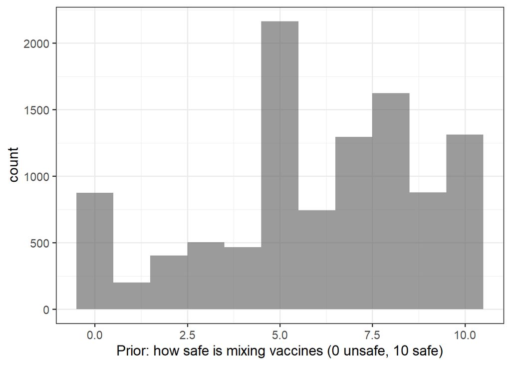

```r
prior_mixed_hist <- thirdwave |>
  ggplot(aes(prior_mixed)) +
  geom_histogram(binwidth = 1, alpha = 0.6) +
  xlab("Prior: how safe is mixing vaccines (0 unsafe, 10 safe)") +
  theme_bw(base_size = 14)

prior_mixed_hist
```

## 4.5 Table 2. Experimental design

Hardcoded in the paper.

```r
knitr::kable(
  tibble::tribble(
    ~Factor, ~Level,
    "$T_1$ Science updating ($\\alpha$)", "(0) No video; (1) Video, changing evidence is normal science",
    "$T_2$ Sender ($q$)", "(0) government; (1) scientific institution (STIKO)",
    "$T_3$ Message", "(1) safe-safe; (2) unsafe-unsafe; (3) unsafe-safe; (4) safe-unsafe",
    "$T_4$ Baseline (safe/unsafe)", "(0) $T_3 \\in \\{1,4\\}$; (1) $T_3 \\in \\{2,3\\}$",
    "$T_5$ Inconsistent message ($s$)", "(0) $T_3 \\in \\{1,2\\}$; (1) $T_3 \\in \\{3,4\\}$"
  ),
  caption = "Table 2. Experimental design: Factors and levels.",
  escape = FALSE
)
```

Table 2. Experimental design: Factors and levels.

| Factor | Level |
| --- | --- |
| $T_1$ Science updating ($\alpha$) | (0) No video; (1) Video, changing evidence is normal science |
| $T_2$ Sender ($q$) | (0) government; (1) scientific institution (STIKO) |
| $T_3$ Message | (1) safe-safe; (2) unsafe-unsafe; (3) unsafe-safe; (4) safe-unsafe |
| $T_4$ Baseline (safe/unsafe) | (0) $T_3 \in \{1,4\}$; (1) $T_3 \in \{2,3\}$ |
| $T_5$ Inconsistent message ($s$) | (0) $T_3 \in \{1,2\}$; (1) $T_3 \in \{3,4\}$ |

## 4.6 Figure 4. Raw data patterns disaggregated by priors

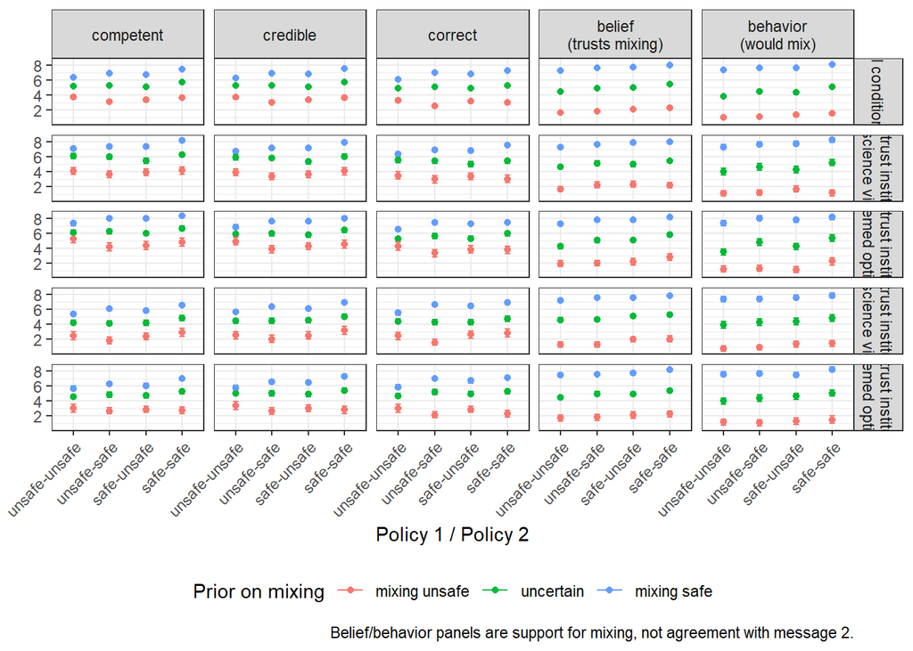

Figure 4. Raw data patterns disaggregated by priors. Outcomes given experimental conditions.

```r
summary_data <-
  thirdwave |>
  mutate(
    prior = prior_group(prior_mixed),
    science = info_treat,
    trust = sender_treat,
    Z = paste0(safe_time1, "/", safe_time2)
  ) |>
  transmute(
    safe_time1, safe_time2, science, trust, Z, prior,
    credible = as.numeric(credible),
    competent = as.numeric(competent),
    correct = as.numeric(correct),
    convinced = post_mixed,
    act = behav_mixed
  ) |>
  pivot_longer(
    c(credible, competent, correct, convinced, act),
    names_to = "Y",
    values_to = "val"
  ) |>
  group_by(safe_time1, safe_time2, science, trust, Z, Y, prior) |>
  summarise(
    n = sum(!is.na(val)),
    mean = mean(val, na.rm = TRUE),
    sd = sd(val, na.rm = TRUE),
    se = sd / sqrt(n),
    tcrit = qt(0.975, df = pmax(n - 1, 1)),
    lwr = mean - tcrit * se,
    upr = mean + tcrit * se,
    .groups = "drop"
  ) |>
  mutate(
    trust_lab = if_else(trust == 1, "high-trust institution", "low-trust institution"),
    science_lab = science_lab(science),
    cond = paste(trust_lab, science_lab, sep = "\n"),
    cond = factor(
      cond,
      levels = c(
        paste("high-trust institution", science_lab(0), sep = "\n"),
        paste("high-trust institution", science_lab(1), sep = "\n"),
        paste("low-trust institution", science_lab(0), sep = "\n"),
        paste("low-trust institution", science_lab(1), sep = "\n")
      )
    ),
    Z = recode(
      Z,
      "0/0" = "unsafe-unsafe",
      "0/1" = "unsafe-safe",
      "1/0" = "safe-unsafe",
      "1/1" = "safe-safe"
    ),
    Z = factor(Z, c("unsafe-unsafe", "unsafe-safe", "safe-unsafe", "safe-safe"))
  )

all_row <- summary_data |>
  group_by(safe_time1, safe_time2, Z, Y, prior) |>
  summarise(
    N = sum(n),
    mu = sum(mean * n) / N,
    var_num = sum((n - 1) * sd^2 + n * (mean - mu)^2),
    sd = sqrt(var_num / pmax(N - 1, 1)),
    se = sd / sqrt(N),
    tcrit = qt(0.975, df = pmax(N - 1, 1)),
    lwr = mu - tcrit * se,
    upr = mu + tcrit * se,
    .groups = "drop"
  ) |>
  transmute(
    safe_time1, safe_time2, Z, Y, prior,
    n = N, mean = mu, sd, se, tcrit, lwr, upr,
    trust_lab = NA_character_, science_lab = NA_character_,
    cond = factor("All conditions", levels = c("All conditions", levels(summary_data$cond)))
  )

summary_data <- bind_rows(
  all_row,
  summary_data |> mutate(cond = fct_relevel(cond, "All conditions"))
) |>
  mutate(
    Y = factor(
      Y,
      c("competent", "credible", "correct", "convinced", "act"),
      c("competent", "credible", "correct", "belief\n(trusts mixing)", "behavior\n(would mix)")
    )
  )

raw_patterns_disagg <- ggplot(summary_data, aes(x = Z, y = mean, color = prior)) +
  facet_grid(cond ~ Y, labeller = label_value) +
  geom_point() +
  geom_errorbar(aes(ymin = lwr, ymax = upr), width = 0.15) +
  theme_bw() +
  theme(
    axis.text.x = element_text(angle = 45, hjust = 1, vjust = 1),
    legend.position = "bottom"
  ) +
  labs(
    x = "Policy 1 / Policy 2",
    y = "",
    color = "Prior on mixing",
    caption = "Belief/behavior panels are support for mixing, not agreement with message 2."
  )

raw_patterns_disagg
```

```r
ggsave(file.path(fig_dir, "raw_disagg.pdf"), raw_patterns_disagg, width = 8, height = 8)
```

## 4.7 Table 3. Fully saturated model

Estimand is unchanged. Labels distinguish Belief/Behave (agreement with message 2) from belief updating.

```r
saturated <- fit_saturated_list(thirdwave)

tab_sat <- write_texreg(
  saturated,
  file = file.path(fig_dir, "tab_1_full.tex"),
  caption = "Fully saturated model",
  label = "table:saturated"
)
```

```r
texreg::htmlreg(
  saturated,
  include.ci = FALSE,
  custom.model.names = mod_names,
  caption = "Table 3. Fully saturated model. Belief (msg 2) and Behave (msg 2) are recoded agreement with the second recommendation, not belief updating. Treatments demeaned (Lin 2013).",
  stars = c(0.01, 0.05, 0.1),
  custom.coef.map = custom.coef.map,
  doctype = FALSE
)
```

Table 3. Fully saturated model. Belief (msg 2) and Behave (msg 2) are recoded agreement with the second recommendation, not belief updating. Treatments demeaned (Lin 2013).

|  | Credible | Competent | Correct | Belief (msg 2) | Behave (msg 2) |
| --- | --- | --- | --- | --- | --- |
| Inconsistent | -0.23*** | -0.25*** | -0.02 | -0.43*** | -0.37*** |
|  | (0.05) | (0.05) | (0.06) | (0.06) | (0.08) |
| Scientific (sender identity) | 1.01*** | 1.51*** | 0.61*** | 0.02 | 0.09 |
|  | (0.05) | (0.05) | (0.06) | (0.06) | (0.08) |
| Science (deemed optimum can change) | 0.28*** | 0.34*** | 0.26*** | 0.10* | 0.15** |
|  | (0.05) | (0.05) | (0.06) | (0.06) | (0.08) |
| Inconsistent $\times$ Scientific | -0.04 | -0.08 | -0.15 | -0.07 | -0.07 |
|  | (0.11) | (0.11) | (0.11) | (0.12) | (0.15) |
| Inconsistent $\times$ Science | 0.09 | 0.13 | 0.15 | -0.18 | -0.09 |
|  | (0.11) | (0.11) | (0.11) | (0.12) | (0.15) |
| Sender: scientific $\times$ Science | 0.04 | 0.10 | 0.00 | 0.05 | 0.08 |
|  | (0.11) | (0.11) | (0.11) | (0.12) | (0.15) |
| Inconsistent $\times$ Scientific $\times$ Science | -0.10 | -0.10 | -0.18 | -0.40* | -0.22 |
|  | (0.21) | (0.22) | (0.23) | (0.24) | (0.30) |
| R<sup>2</sup> | 0.05 | 0.08 | 0.02 | 0.06 | 0.02 |
| Adj. R<sup>2</sup> | 0.04 | 0.08 | 0.02 | 0.06 | 0.01 |
| Num. obs. | 10456 | 10456 | 10456 | 10456 | 10456 |
| RMSE | 2.74 | 2.81 | 2.89 | 3.06 | 3.85 |

***p < 0.01; **p < 0.05; *p < 0.1

## 4.8 Figure 5. ITT and LATE

Assignment (`inconsistent`, 0/1) instruments perceived inconsistency (`treatment_measurement`).

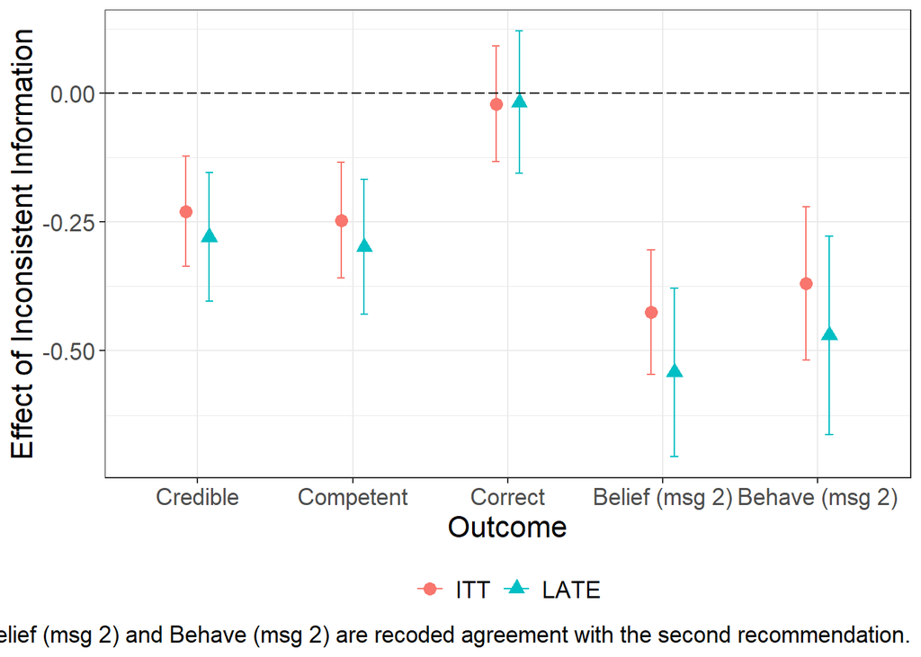

Figure 5. Intent-to-treat (ITT) and local average treatment (LATE) effect.

```r
models_basic <- lapply(outcomes, function(y) {
  lm_robust(as.formula(paste(y, "~ inconsistent")), data = thirdwave)
})
names(models_basic) <- outcomes

subfigure_1_itt <- lapply(models_basic, tidy) |>
  bind_rows(.id = "outcome") |>
  mutate(Model = "ITT") |>
  filter(term != "(Intercept)") |>
  mutate(outcome = factor(outcome, outcomes, outcome_labels)) |>
  select(-any_of("df"))

models_iv <- lapply(outcomes, function(y) {
  iv_robust(
    as.formula(paste(y, "~ treatment_measurement | inconsistent")),
    data = thirdwave
  )
})
names(models_iv) <- outcomes

subfigure_1_iv <- lapply(models_iv, tidy) |>
  bind_rows(.id = "outcome") |>
  mutate(Model = "LATE") |>
  filter(term != "(Intercept)") |>
  mutate(outcome = factor(outcome, outcomes, outcome_labels)) |>
  select(-any_of("df"))

data_figure5 <- bind_rows(subfigure_1_itt, subfigure_1_iv)

figure_5 <- data_figure5 |>
  ggplot(aes(estimate, outcome, color = Model, shape = Model)) +
  geom_point(position = position_dodge(width = 0.3), size = 3) +
  geom_errorbar(
    aes(xmin = conf.low, xmax = conf.high),
    position = position_dodge(width = 0.3),
    width = 0.1
  ) +
  geom_vline(xintercept = 0, linetype = "longdash") +
  xlab("Effect of Inconsistent Information") +
  ylab("Outcome") +
  labs(
    caption = "Belief (msg 2) and Behave (msg 2) are recoded agreement with the second recommendation."
  ) +
  theme_bw() +
  theme(legend.position = "bottom", legend.title = element_blank(), text = element_text(size = 16)) +
  coord_flip()

figure_5
```

```r
ggsave(file.path(fig_dir, "figure_1.pdf"), figure_5, width = 8, height = 5)
ggsave(file.path(fig_dir, "figure_5.pdf"), figure_5, width = 8, height = 5)
```

```r
show_htmlreg(
  models_basic,
  caption = "ITT companion to Figure 5. Inconsistency assignment. Same outcomes as Table 3."
)
```

ITT companion to Figure 5. Inconsistency assignment. Same outcomes as Table 3.

|  | Credible | Competent | Correct | Belief (msg 2) | Behave (msg 2) |
| --- | --- | --- | --- | --- | --- |
| Inconsistent | -0.23*** | -0.25*** | -0.02 | -0.43*** | -0.37*** |
|  | (0.05) | (0.06) | (0.06) | (0.06) | (0.08) |
| R<sup>2</sup> | 0.00 | 0.00 | 0.00 | 0.00 | 0.00 |
| Adj. R<sup>2</sup> | 0.00 | 0.00 | -0.00 | 0.00 | 0.00 |
| Num. obs. | 10456 | 10456 | 10456 | 10456 | 10456 |
| RMSE | 2.80 | 2.93 | 2.92 | 3.14 | 3.88 |

***p < 0.01; **p < 0.05; *p < 0.1

```r
show_htmlreg(
  models_iv,
  caption = "LATE/IV companion to Figure 5. Perceived inconsistency instrumented by assignment. Same outcomes as Table 3.",
  coef_map = iv_coef_map
)
```

LATE/IV companion to Figure 5. Perceived inconsistency instrumented by assignment. Same outcomes as Table 3.

|  | Credible | Competent | Correct | Belief (msg 2) | Behave (msg 2) |
| --- | --- | --- | --- | --- | --- |
| Perceived inconsistency | -0.28*** | -0.30*** | -0.02 | -0.54*** | -0.47*** |
|  | (0.06) | (0.07) | (0.07) | (0.08) | (0.10) |
| R<sup>2</sup> | 0.13 | 0.13 | 0.01 | -0.19 | -0.08 |
| Adj. R<sup>2</sup> | 0.13 | 0.13 | 0.01 | -0.19 | -0.08 |
| Num. obs. | 10357 | 10357 | 10357 | 10357 | 10357 |
| RMSE | 2.61 | 2.73 | 2.90 | 3.44 | 4.04 |

***p < 0.01; **p < 0.05; *p < 0.1

## 4.9 Figure 6. Inconsistency conditional on science video

Conditional coefficients of inconsistency at no-video and video, from the same demeaned saturated specification as Table 3. Figure 6 plots only Credible, Competent, and Correct (not Belief/Behave). Vertical error bars (`geom_errorbar` with ymin/ymax). The paper text on this figure concerns the *interaction* (whether the video weakens the inconsistency penalty), not the main effect of the video.

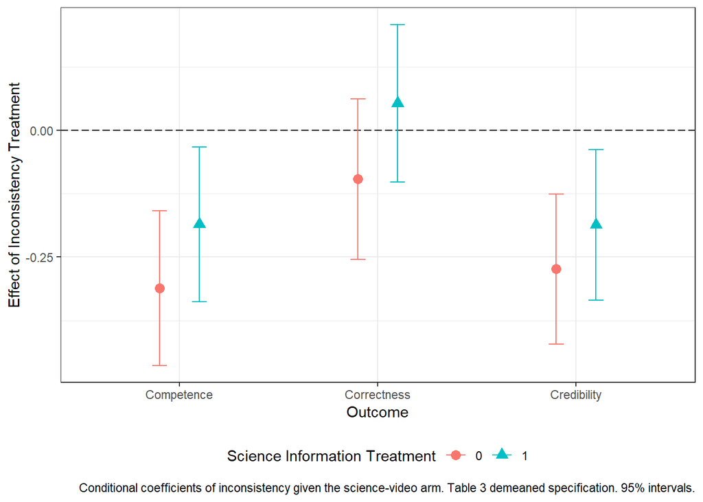

Figure 6. Effect of Inconsistent Information conditional on the receipt of scientific information intervention.

```r
mean_science <- mean(as.numeric(thirdwave$science), na.rm = TRUE)
fig6_idx <- 1:3
fig6_order <- c("Competent", "Correct", "Credible")
fig6_xlab <- c("Competence", "Correctness", "Credibility")

science_me <- map_dfr(fig6_idx, function(i) {
  fit <- saturated[[i]]
  b <- coef(fit)
  V <- vcov(fit)
  inc <- "inconsistent"
  int <- "inconsistent:science"
  tibble(science_raw = c(0, 1), outcome = outcome_labels[i]) |>
    mutate(
      s_d = science_raw - mean_science,
      estimate = b[[inc]] + b[[int]] * s_d,
      se = sqrt(
        V[inc, inc] + (s_d^2) * V[int, int] + 2 * s_d * V[inc, int]
      ),
      conf.low = estimate - 1.96 * se,
      conf.high = estimate + 1.96 * se,
      science = factor(science_raw, levels = c(0, 1), labels = c("0", "1"))
    )
}) |>
  mutate(
    outcome = factor(outcome, fig6_order, fig6_xlab)
  )

figure_6 <- science_me |>
  ggplot(aes(outcome, estimate, color = science, shape = science)) +
  geom_hline(yintercept = 0, linetype = "longdash") +
  geom_point(position = position_dodge(width = 0.4), size = 3) +
  geom_errorbar(
    aes(ymin = conf.low, ymax = conf.high),
    position = position_dodge(width = 0.4),
    width = 0.15
  ) +
  xlab("Outcome") +
  ylab("Effect of Inconsistency Treatment") +
  labs(
    color = "Science Information Treatment",
    shape = "Science Information Treatment",
    caption = "Conditional coefficients of inconsistency given the science-video arm. Table 3 demeaned specification. 95% intervals."
  ) +
  theme_bw() +
  theme(legend.position = "bottom")

figure_6
```

```r
ggsave(file.path(fig_dir, "figure_3_new.pdf"), figure_6, width = 8, height = 5)
ggsave(file.path(fig_dir, "figure_6.pdf"), figure_6, width = 8, height = 5)
```

# 5 5. SI

## 5.1 Table A.1. Statistical models (OxCGRT)

Country-day OxCGRT (2022-07 legacy snapshot) merged with Pulejo and Querubin (2021) election data. Table A.1 is the Government Response Index specification, N = 65. Appendix prose describes the Containment Health Index; the printed coefficients match GRI.

```r
oxcgrt_raw <- if (nzchar(oxcgrt_csv) && file.exists(oxcgrt_csv)) {
  read.csv(oxcgrt_csv)
} else {
  read.csv(oxcgrt_url)
}
oxcgrt_raw <- transform(oxcgrt_raw, Date = as.Date(as.character(Date), "%Y%m%d"))

policy_variables <- c(
  "ContainmentHealthIndex",
  "StringencyIndex",
  "GovernmentResponseIndex",
  "C1_School.closing",
  "C2_Workplace.closing",
  "C3_Cancel.public.events",
  "C4_Restrictions.on.gatherings",
  "C5_Close.public.transport",
  "C6_Stay.at.home.requirements",
  "C7_Restrictions.on.internal.movement",
  "C8_International.travel.controls",
  "H1_Public.information.campaigns",
  "H2_Testing.policy",
  "H3_Contact.tracing",
  "H6_Facial.Coverings",
  "H7_Vaccination.policy",
  "H8_Protection.of.elderly.people"
)

oxcgrt_daily <- oxcgrt_raw |>
  subset(Date < as.Date("2020-05-29")) |>
  dplyr::filter(Jurisdiction == "NAT_TOTAL") |>
  dplyr::select(CountryCode, CountryName, Date, dplyr::any_of(policy_variables))

election <- read_dta(election_file) |>
  dplyr::select(
    countryname,
    timetocase1,
    maxconsecutiveterms,
    termlength,
    canrun,
    electionproximity_yrs,
    electionproximity_yrs_canrun,
    Z_bci_bci,
    Z_cspf_sfi
  )

oxcgrt_merged <- merge(
  oxcgrt_daily,
  election,
  by.x = "CountryName",
  by.y = "countryname"
)

policy_present <- intersect(policy_variables, names(oxcgrt_merged))

oxcgrt <- oxcgrt_merged |>
  group_by(CountryName) |>
  summarize(
    across(
      all_of(policy_present),
      .fns = list(
        sd = \(x) sd(x, na.rm = TRUE),
        fluctuation = \(x) sd(diff(x), na.rm = TRUE),
        changes = \(x) sum(diff(x) != 0, na.rm = TRUE),
        reversals1 = \(x) sum(diff(sign(diff(x))) != 0, na.rm = TRUE)
      ),
      .names = "{.col}_{.fn}"
    ),
    .groups = "drop"
  ) |>
  merge(election, by.x = "CountryName", by.y = "countryname")

c(n_countries = nrow(oxcgrt))
```

```
n_countries
         65
```

```r
a1_rhs <- "canrun + electionproximity_yrs + electionproximity_yrs_canrun"
a1_models <- list(
  sd = lm_robust(as.formula(paste("GovernmentResponseIndex_sd ~", a1_rhs)), data = oxcgrt),
  fluctuations = lm_robust(
    as.formula(paste("GovernmentResponseIndex_fluctuation ~", a1_rhs)),
    data = oxcgrt
  ),
  changes = lm_robust(
    as.formula(paste("GovernmentResponseIndex_changes ~", a1_rhs)),
    data = oxcgrt
  ),
  reversals = lm_robust(
    as.formula(paste("GovernmentResponseIndex_reversals1 ~", a1_rhs)),
    data = oxcgrt
  )
)
a1_names <- c("sd", "fluctuations", "changes", "reversals")
a1_coef_map <- list(
  "canrun" = "Can Run",
  "electionproximity_yrs" = "Electoral Proximity",
  "electionproximity_yrs_canrun" = "Proximity $\\times$ Can Run"
)

tab_a1 <- texreg::texreg(
  a1_models,
  include.ci = FALSE,
  omit.coef = "(Intercept)",
  custom.model.names = a1_names,
  custom.coef.map = a1_coef_map,
  caption = "Statistical models",
  label = "table:coefficients:policy",
  stars = c(0.001, 0.01, 0.05, 0.1)
)
write(tab_a1, file = file.path(fig_dir, "tab_a1_policy.tex"))
```

```r
show_htmlreg(
  a1_models,
  caption = "Table A.1. Statistical models. Government Response Index; N = 65. Can Run, Electoral Proximity, and their interaction.",
  names = a1_names,
  coef_map = list(
    "canrun" = "Can Run",
    "electionproximity_yrs" = "Electoral Proximity",
    "electionproximity_yrs_canrun" = "Proximity × Can Run"
  ),
  omit.coef = "(Intercept)"
)
```

Table A.1. Statistical models. Government Response Index; N = 65. Can Run, Electoral Proximity, and their interaction.

|  | sd | fluctuations | changes | reversals |
| --- | --- | --- | --- | --- |
| Can Run | -8.07** | -20.13*** | -24.91 | -23.51* |
|  | (3.62) | (5.96) | (15.40) | (12.46) |
| Electoral Proximity | 0.77 | 3.12** | 5.79* | 3.21 |
|  | (0.76) | (1.25) | (3.27) | (2.76) |
| Proximity × Can Run | -2.62** | -5.13*** | -4.30 | -3.28 |
|  | (1.01) | (1.85) | (5.08) | (4.45) |
| R<sup>2</sup> | 0.19 | 0.13 | 0.05 | 0.06 |
| Adj. R<sup>2</sup> | 0.15 | 0.08 | 0.00 | 0.01 |
| Num. obs. | 65 | 65 | 65 | 65 |
| RMSE | 4.99 | 12.44 | 34.89 | 30.38 |

***p < 0.01; **p < 0.05; *p < 0.1

## 5.2 Figure A.1. The Effect of Elections on Policy Changes

Conditional coefficients on proximity × can-run for the CHI component indicators.

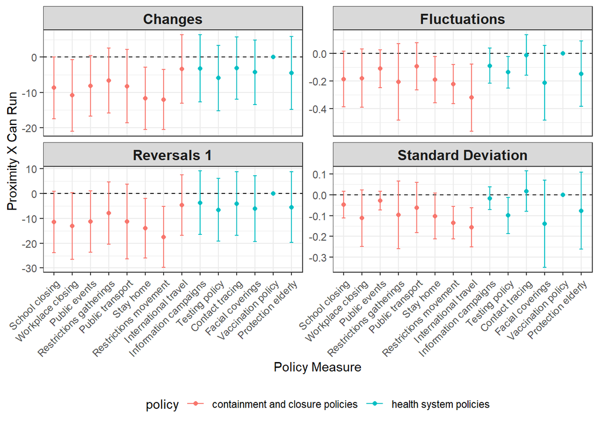

Figure A.1. The Effect of Elections on Policy Changes.

```r
policy_labels <- c(
  "C1_School.closing" = "School closing",
  "C2_Workplace.closing" = "Workplace closing",
  "C3_Cancel.public.events" = "Public events",
  "C4_Restrictions.on.gatherings" = "Restrictions gatherings",
  "C5_Close.public.transport" = "Public transport",
  "C6_Stay.at.home.requirements" = "Stay home",
  "C7_Restrictions.on.internal.movement" = "Restrictions movement",
  "C8_International.travel.controls" = "International travel",
  "H1_Public.information.campaigns" = "Information campaigns",
  "H2_Testing.policy" = "Testing policy",
  "H3_Contact.tracing" = "Contact tracing",
  "H6_Facial.Coverings" = "Facial coverings",
  "H7_Vaccination.policy" = "Vaccination policy",
  "H8_Protection.of.elderly.people" = "Protection elderly"
)

indicator_vars <- setdiff(
  policy_present,
  c("ContainmentHealthIndex", "StringencyIndex", "GovernmentResponseIndex")
)

a1_fig_dat <- map_dfr(indicator_vars, function(variable) {
  map_dfr(c("_sd", "_fluctuation", "_changes", "_reversals1"), function(measure) {
    outcome <- paste0(variable, measure)
    if (!outcome %in% names(oxcgrt)) {
      return(NULL)
    }
    fit <- lm(as.formula(paste(outcome, "~", a1_rhs)), data = oxcgrt)
    sm <- summary(fit)$coef
    tibble(
      outcome = outcome,
      coef_value = unname(sm["electionproximity_yrs_canrun", "Estimate"]),
      std_error = unname(sm["electionproximity_yrs_canrun", "Std. Error"]),
      group = measure
    )
  })
})

fig_pol_updating <- a1_fig_dat |>
  mutate(
    policy = case_when(
      substr(outcome, 1, 1) == "C" ~ "containment and closure policies",
      substr(outcome, 1, 1) == "H" ~ "health system policies",
      TRUE ~ NA_character_
    ),
    outcome = stringr::str_remove_all(outcome, "_sd|_fluctuation|_changes|_reversals1"),
    group = recode(
      group,
      "_sd" = "Standard Deviation",
      "_fluctuation" = "Fluctuations",
      "_changes" = "Changes",
      "_reversals1" = "Reversals 1"
    )
  ) |>
  ggplot(aes(
    x = factor(outcome, levels = names(policy_labels)),
    y = coef_value,
    color = policy
  )) +
  geom_hline(yintercept = 0, linetype = "dashed", color = "black") +
  geom_point() +
  geom_errorbar(
    aes(ymin = coef_value - 1.96 * std_error, ymax = coef_value + 1.96 * std_error),
    width = 0.2
  ) +
  labs(x = "Policy Measure", y = "Proximity X Can Run") +
  facet_wrap(~group, scales = "free_y", ncol = 2) +
  scale_x_discrete(labels = policy_labels) +
  theme_bw() +
  theme(
    strip.text = element_text(size = 12, face = "bold"),
    axis.text.x = element_text(angle = 45, hjust = 1, vjust = 1),
    legend.position = "bottom"
  )

fig_pol_updating
```

```r
ggsave(file.path(fig_dir, "fig_pol_updating.pdf"), fig_pol_updating, width = 8, height = 5)
```

## 5.3 Figure C.1. Survey instrument (introduction and treatments)

Static Overleaf screenshot. Not generated by this qmd. Introduction, treatment messages, and manipulation checks (`Screenshot_2021-09-08 Umfrage(1–5).png`).

## 5.4 Figure C.2. Survey instrument (timing)

Static Overleaf screenshot. Not generated by this qmd. Timing questions (`Screenshot_2021-09-08 Umfrage(6–8).png`).

## 5.5 Table D.1. Summary statistics

```r
summ_vars <- thirdwave |>
  select(
    age, gender, vaccination_status, vaccine_type, covid_invection,
    trust_government, trust_experts, trust_state_gov, trust_media, trust_stiko,
    political_interest, party_id, prior_pfm, prior_vac_pfm, salience_vac,
    credible, competent, correct, prior_mixed, post_mixed, behav_mixed,
    incumbent_voting, treatment_measurement
  )

summary_table <- summ_vars |>
  mutate(across(everything(), as.numeric)) |>
  summarise(across(
    everything(),
    list(
      N = \(x) sum(!is.na(x)),
      Mean = \(x) mean(x, na.rm = TRUE),
      `Std. Dev.` = \(x) sd(x, na.rm = TRUE),
      Min = \(x) min(x, na.rm = TRUE),
      `Pctl. 25` = \(x) quantile(x, 0.25, na.rm = TRUE),
      `Pctl. 75` = \(x) quantile(x, 0.75, na.rm = TRUE),
      Max = \(x) max(x, na.rm = TRUE)
    ),
    .names = "{.col}__{.fn}"
  )) |>
  pivot_longer(everything(), names_to = c("Variable", "Statistic"), names_sep = "__") |>
  pivot_wider(names_from = "Statistic", values_from = "value") |>
  arrange(Variable)

knitr::kable(
  summary_table,
  digits = 2,
  col.names = c("Variable", "N", "Mean", "Std. Dev.", "Min", "Pctl. 25", "Pctl. 75", "Max"),
  caption = "Table D.1. Summary Statistics"
) |>
  kableExtra::kable_styling(full_width = FALSE)
```

Table D.1. Summary Statistics

| Variable | N | Mean | Std. Dev. | Min | Pctl. 25 | Pctl. 75 | Max |
| --- | --- | --- | --- | --- | --- | --- | --- |
| age | 10456 | 49.79 | 14.50 | 18 | 38 | 61 | 76 |
| behav_mixed | 10456 | 5.44 | 3.86 | 0 | 1 | 10 | 10 |
| competent | 10456 | 5.74 | 2.93 | 0 | 4 | 8 | 11 |
| correct | 10456 | 5.51 | 2.92 | 0 | 4 | 8 | 10 |
| covid_invection | 10456 | 1.97 | 0.18 | 1 | 2 | 2 | 2 |
| credible | 10456 | 5.73 | 2.80 | 0 | 4 | 8 | 10 |
| gender | 10456 | 1.54 | 0.50 | 1 | 1 | 2 | 3 |
| incumbent_voting | 10456 | 1.63 | 0.48 | 1 | 1 | 2 | 2 |
| party_id | 10456 | 5.08 | 2.80 | 1 | 3 | 8 | 9 |
| political_interest | 10456 | 2.00 | 0.86 | 1 | 1 | 2 | 4 |
| post_mixed | 10456 | 5.72 | 3.07 | 0 | 4 | 8 | 10 |
| prior_mixed | 10456 | 6.00 | 2.90 | 0 | 5 | 8 | 10 |
| prior_pfm | 10456 | -0.49 | 2.76 | -5 | -3 | 2 | 5 |
| prior_vac_pfm | 10456 | -0.37 | 2.85 | -5 | -3 | 2 | 5 |
| salience_vac | 10456 | 2.20 | 1.16 | 1 | 1 | 3 | 5 |
| treatment_measurement | 10357 | 5.10 | 2.94 | 0 | 3 | 7 | 10 |
| trust_experts | 10456 | 2.65 | 1.01 | 0 | 2 | 3 | 4 |
| trust_government | 10456 | 1.85 | 1.13 | 0 | 1 | 3 | 4 |
| trust_media | 10456 | 1.67 | 1.03 | 0 | 1 | 2 | 4 |
| trust_state_gov | 10456 | 1.91 | 1.09 | 0 | 1 | 3 | 4 |
| trust_stiko | 10456 | 2.47 | 1.12 | 0 | 2 | 3 | 4 |
| vaccination_status | 10456 | 1.29 | 2.73 | 1 | 1 | 1 | 99 |
| vaccine_type | 8248 | 1.94 | 1.58 | 1 | 1 | 3 | 6 |

```r
writeLines(
  knitr::kable(summary_table, format = "latex", digits = 2, booktabs = TRUE),
  file.path(fig_dir, "tab_summary_stats.tex")
)
```

## 5.6 Figure D.1. Prior and posterior beliefs

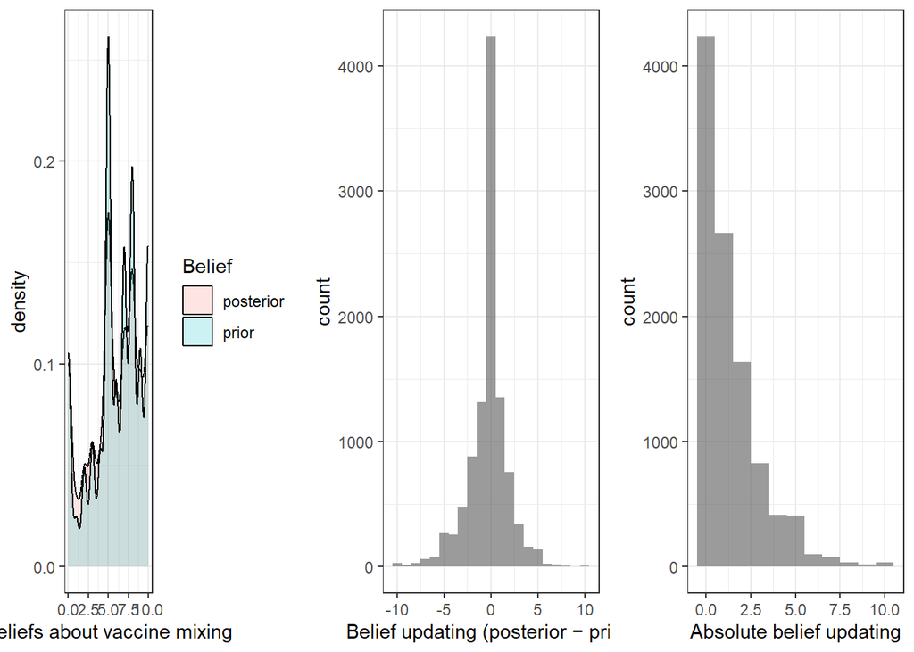

Figure D.1. Prior and Posterior Beliefs, Belief Updating

```r
prior <- tibble(value = thirdwave$prior_mixed, Belief = "prior")
post <- tibble(value = thirdwave$post_mixed, Belief = "posterior")

prior_posterior <- bind_rows(prior, post) |>
  ggplot(aes(value, fill = Belief)) +
  geom_density(alpha = 0.2) +
  xlab("Beliefs about vaccine mixing") +
  theme_bw()

belief_update_plot <- thirdwave |>
  ggplot(aes(belief_update)) +
  geom_histogram(binwidth = 1, alpha = 0.6) +
  xlab("Belief updating (posterior − prior)") +
  theme_bw()

belief_update_abs_plot <- thirdwave |>
  ggplot(aes(belief_update_abs)) +
  geom_histogram(binwidth = 1, alpha = 0.6) +
  xlab("Absolute belief updating") +
  theme_bw()

fig_13 <- grid.arrange(prior_posterior, belief_update_plot, belief_update_abs_plot, ncol = 3)
```

```r
ggsave(file.path(fig_dir, "figure_13.pdf"), fig_13, width = 10, height = 4)
```

## 5.7 Table E.1. Science-video manipulation check

Science video: share who say contradicting studies are compatible with scientific progress.

```r
man_science <- lm_robust(
  I(manipulation_science == 1) ~ science,
  data = thirdwave
)
summary(man_science)
```

```
Call:
lm_robust(formula = I(manipulation_science == 1) ~ science, data = thirdwave)

Standard error type:  HC2

Coefficients:
            Estimate Std. Error t value  Pr(>|t|) CI Lower CI Upper    DF
(Intercept)  0.69343   0.006375 108.774 0.000e+00  0.68093  0.70592 10454
science      0.06538   0.008699   7.515 6.136e-14  0.04833  0.08243 10454

Multiple R-squared:  0.005373 , Adjusted R-squared:  0.005278
F-statistic: 56.48 on 1 and 10454 DF,  p-value: 6.136e-14
```

```r
tab_man_science <- texreg::texreg(
  man_science,
  include.ci = FALSE,
  caption = "Science-video manipulation check",
  label = "tab:man_science",
  stars = c(0.01, 0.05, 0.1),
  custom.coef.map = list("(Intercept)" = "Constant", "science" = "Science video")
)
write(tab_man_science, file = file.path(fig_dir, "tab_man_science.tex"))
```

```r
show_htmlreg(
  man_science,
  caption = "Table E.1. Science-video manipulation check (Inconsistencies in Science).",
  names = "Inconsistencies in Science",
  coef_map = list("(Intercept)" = "Constant", "science" = "Science video")
)
```

Table E.1. Science-video manipulation check (Inconsistencies in Science).

|  | Inconsistencies in Science |
| --- | --- |
| Constant | 0.69*** |
|  | (0.01) |
| Science video | 0.07*** |
|  | (0.01) |
| R<sup>2</sup> | 0.01 |
| Adj. R<sup>2</sup> | 0.01 |
| Num. obs. | 10456 |
| RMSE | 0.44 |

***p < 0.01; **p < 0.05; *p < 0.1

## 5.8 Table E.2. Treatment compliance (first stage)

Perceived inconsistency (first stage for the IV).

```r
man_iv <- lm_robust(treatment_measurement ~ inconsistent, data = thirdwave)
summary(man_iv)
```

```
Call:
lm_robust(formula = treatment_measurement ~ inconsistent, data = thirdwave)

Standard error type:  HC2

Coefficients:
             Estimate Std. Error t value  Pr(>|t|) CI Lower CI Upper    DF
(Intercept)    4.6947    0.04045  116.06 0.000e+00   4.6154   4.7740 10355
inconsistent   0.8085    0.05717   14.14 5.354e-45   0.6965   0.9206 10355

Multiple R-squared:  0.01895 ,  Adjusted R-squared:  0.01886
F-statistic:   200 on 1 and 10355 DF,  p-value: < 2.2e-16
```

```r
tab_man_iv <- texreg::texreg(
  man_iv,
  include.ci = FALSE,
  caption = "Treatment compliance (perceived inconsistency)",
  label = "TreatmentCompliance",
  stars = c(0.01, 0.05, 0.1),
  custom.coef.map = list(
    "(Intercept)" = "Constant",
    "inconsistent" = "Instrument (inconsistent information)"
  )
)
write(tab_man_iv, file = file.path(fig_dir, "tab_treatment_compliance.tex"))
```

```r
show_htmlreg(
  man_iv,
  caption = "Table E.2. Treatment Compliance.",
  names = "Treatment Measurement",
  coef_map = list(
    "(Intercept)" = "Constant",
    "inconsistent" = "Instrument (inconsistent information)"
  )
)
```

Table E.2. Treatment Compliance.

|  | Treatment Measurement |
| --- | --- |
| Constant | 4.69*** |
|  | (0.04) |
| Instrument (inconsistent information) | 0.81*** |
|  | (0.06) |
| R<sup>2</sup> | 0.02 |
| Adj. R<sup>2</sup> | 0.02 |
| Num. obs. | 10357 |
| RMSE | 2.91 |

***p < 0.01; **p < 0.05; *p < 0.1

## 5.9 Table E.3. Manipulation perceived timing

Perceived timing of recommendations.

```r
man_t1_safe <- lm_robust(as.numeric(manipulation_time1) ~ safe_time1, data = thirdwave)
man_t1_unsafe <- lm_robust(as.numeric(manipulation_time1) ~ unsafe_time1, data = thirdwave)
man_t2_safe <- lm_robust(as.numeric(manipulation_time2) ~ safe_time2, data = thirdwave)
man_t2_unsafe <- lm_robust(as.numeric(manipulation_time2) ~ unsafe_time2, data = thirdwave)

tab_man1 <- texreg::texreg(
  list(man_t1_safe, man_t1_unsafe, man_t2_safe, man_t2_unsafe),
  include.ci = FALSE,
  custom.model.names = c("manipulation t1", "manipulation t1", "manipulation t2", "manipulation t2"),
  caption = "Manipulation perceived timing",
  label = "table:coefficients",
  stars = c(0.001, 0.01, 0.05),
  custom.coef.map = list(
    "safe_time1" = "safe\\_time1",
    "unsafe_time1" = "unsafe\\_time1",
    "safe_time2" = "safe\\_time2",
    "unsafe_time2" = "unsafe\\_time2"
  )
)
write(tab_man1, file = file.path(fig_dir, "tab_man1.tex"))
```

```r
show_htmlreg(
  list(man_t1_safe, man_t1_unsafe, man_t2_safe, man_t2_unsafe),
  caption = "Table E.3. Manipulation perceived timing.",
  names = c("manipulation t1", "manipulation t1", "manipulation t2", "manipulation t2"),
  coef_map = list(
    "safe_time1" = "safe_time1",
    "unsafe_time1" = "unsafe_time1",
    "safe_time2" = "safe_time2",
    "unsafe_time2" = "unsafe_time2"
  )
)
```

Table E.3. Manipulation perceived timing.

|  | manipulation t1 | manipulation t1 | manipulation t2 | manipulation t2 |
| --- | --- | --- | --- | --- |
| safe_time1 | 1.74*** |  |  |  |
|  | (0.04) |  |  |  |
| unsafe_time1 |  | -1.74*** |  |  |
|  |  | (0.04) |  |  |
| safe_time2 |  |  | 1.60*** |  |
|  |  |  | (0.04) |  |
| unsafe_time2 |  |  |  | -1.60*** |
|  |  |  |  | (0.04) |
| R<sup>2</sup> | 0.17 | 0.17 | 0.14 | 0.14 |
| Adj. R<sup>2</sup> | 0.17 | 0.17 | 0.14 | 0.14 |
| Num. obs. | 10456 | 10456 | 10456 | 10456 |
| RMSE | 1.95 | 1.95 | 1.97 | 1.97 |

***p < 0.01; **p < 0.05; *p < 0.1

## 5.10 Table F.1. Inquiry reconciliation

## 5.11 Table F.2. Parameter mapping

## 5.12 Table F.3. Answer strategy

Hardcoded in `appendix.tex` (inquiry reconciliation, parameter mapping, answer strategy). Not generated from the survey file.

## 5.13 Table G.1. Ordering: first message against mixing

## 5.14 Table G.2. Ordering: first message for mixing

Filters use the stored 0/1 `safe_time1`, not a demeaned copy.

```r
sat_0 <- fit_saturated_list(
  filter(thirdwave, safe_time1 == 0),
  rhs = "inconsistent * trusted * science"
)
sat_1 <- fit_saturated_list(
  filter(thirdwave, safe_time1 == 1),
  rhs = "inconsistent * trusted * science"
)

tab_sat_0 <- write_texreg(
  sat_0,
  file = file.path(fig_dir, "tab_1_full_0.tex"),
  caption = "Fully saturated model | first message against mixing",
  label = "table:saturated_0"
)
tab_sat_1 <- write_texreg(
  sat_1,
  file = file.path(fig_dir, "tab_1_full_1.tex"),
  caption = "Fully saturated model | first message supports mixing",
  label = "table:saturated_1"
)
```

```r
texreg::htmlreg(
  sat_0,
  include.ci = FALSE,
  custom.model.names = mod_names,
  caption = "Table G.1. Fully saturated model | first message against mixing",
  stars = c(0.01, 0.05, 0.1),
  custom.coef.map = custom.coef.map,
  doctype = FALSE
)
```

Table G.1. Fully saturated model | first message against mixing

|  | Credible | Competent | Correct | Belief (msg 2) | Behave (msg 2) |
| --- | --- | --- | --- | --- | --- |
| Inconsistent | 0.17** | 0.16** | 0.33*** | 1.02*** | 0.50*** |
|  | (0.08) | (0.08) | (0.08) | (0.09) | (0.11) |
| Scientific (sender identity) | 1.04*** | 1.56*** | 0.69*** | 0.05 | 0.12 |
|  | (0.08) | (0.08) | (0.08) | (0.09) | (0.11) |
| Science (deemed optimum can change) | 0.25*** | 0.33*** | 0.25*** | 0.03 | 0.11 |
|  | (0.08) | (0.08) | (0.08) | (0.09) | (0.11) |
| Inconsistent $\times$ Scientific | -0.17 | -0.26* | -0.30* | 0.07 | 0.00 |
|  | (0.15) | (0.15) | (0.16) | (0.17) | (0.22) |
| Inconsistent $\times$ Science | 0.03 | 0.15 | 0.19 | -0.16 | -0.08 |
|  | (0.15) | (0.15) | (0.16) | (0.17) | (0.22) |
| Sender: scientific $\times$ Science | -0.08 | -0.00 | -0.19 | -0.11 | -0.02 |
|  | (0.15) | (0.15) | (0.16) | (0.17) | (0.22) |
| Inconsistent $\times$ Scientific $\times$ Science | -0.08 | -0.16 | -0.12 | -0.48 | -0.27 |
|  | (0.30) | (0.31) | (0.32) | (0.34) | (0.43) |
| R<sup>2</sup> | 0.04 | 0.08 | 0.02 | 0.03 | 0.00 |
| Adj. R<sup>2</sup> | 0.04 | 0.08 | 0.02 | 0.03 | 0.00 |
| Num. obs. | 5230 | 5230 | 5230 | 5230 | 5230 |
| RMSE | 2.74 | 2.80 | 2.89 | 3.11 | 3.89 |

***p < 0.01; **p < 0.05; *p < 0.1

```r
texreg::htmlreg(
  sat_1,
  include.ci = FALSE,
  custom.model.names = mod_names,
  caption = "Table G.2. Fully saturated model | first message supports mixing",
  stars = c(0.01, 0.05, 0.1),
  custom.coef.map = custom.coef.map,
  doctype = FALSE
)
```

Table G.2. Fully saturated model | first message supports mixing

|  | Credible | Competent | Correct | Belief (msg 2) | Behave (msg 2) |
| --- | --- | --- | --- | --- | --- |
| Inconsistent | -0.63*** | -0.65*** | -0.37*** | -1.87*** | -1.24*** |
|  | (0.08) | (0.08) | (0.08) | (0.08) | (0.11) |
| Scientific (sender identity) | 0.97*** | 1.47*** | 0.54*** | -0.00 | 0.06 |
|  | (0.08) | (0.08) | (0.08) | (0.08) | (0.11) |
| Science (deemed optimum can change) | 0.31*** | 0.36*** | 0.27*** | 0.18** | 0.20* |
|  | (0.08) | (0.08) | (0.08) | (0.08) | (0.11) |
| Inconsistent $\times$ Scientific | 0.10 | 0.10 | -0.01 | -0.20 | -0.14 |
|  | (0.15) | (0.16) | (0.16) | (0.17) | (0.21) |
| Inconsistent $\times$ Science | 0.15 | 0.10 | 0.11 | -0.19 | -0.10 |
|  | (0.15) | (0.16) | (0.16) | (0.17) | (0.21) |
| Sender: scientific $\times$ Science | 0.16 | 0.20 | 0.20 | 0.20 | 0.17 |
|  | (0.15) | (0.16) | (0.16) | (0.17) | (0.21) |
| Inconsistent $\times$ Scientific $\times$ Science | -0.12 | -0.04 | -0.24 | -0.33 | -0.17 |
|  | (0.30) | (0.31) | (0.32) | (0.33) | (0.42) |
| R<sup>2</sup> | 0.05 | 0.08 | 0.02 | 0.09 | 0.03 |
| Adj. R<sup>2</sup> | 0.04 | 0.08 | 0.01 | 0.09 | 0.03 |
| Num. obs. | 5226 | 5226 | 5226 | 5226 | 5226 |
| RMSE | 2.74 | 2.82 | 2.89 | 3.01 | 3.82 |

***p < 0.01; **p < 0.05; *p < 0.1

## 5.15 Table G.3. Saturated model accounting for priors

```r
thirdwave_prior <- thirdwave |>
  mutate(prior = prior_mixed - mean(prior_mixed, na.rm = TRUE))

sat_priors <- lapply(outcomes, function(y) {
  d <- with_demeaned_treatments(thirdwave_prior, c(treatment_vars, "prior"))
  lm_robust(
    as.formula(paste(y, "~ inconsistent * trusted * science * prior * safe_time1")),
    data = d
  )
})

tab_sat_priors <- write_texreg(
  sat_priors,
  file = file.path(fig_dir, "tab_1_full_priors.tex"),
  caption = "Fully saturated model | accounting for priors",
  label = "table:saturated_priors"
)

prior_interactions <- list(
  "inconsistent:trusted" = "Inconsistent $\\times$ Sender: scientific",
  "inconsistent:science" = "Inconsistent $\\times$ Science",
  "prior" = "Priors",
  "inconsistent:prior" = "Inconsistent $\\times$ Priors",
  "trusted:prior" = "Sender: scientific $\\times$ Priors",
  "science:prior" = "Science (deemed optimum can change) $\\times$ Priors",
  "inconsistent:safe_time1" = "Inconsistent $\\times$ Initial safe",
  "prior:safe_time1" = "Initial safe $\\times$ Priors",
  "inconsistent:prior:safe_time1" = "Inconsistent $\\times$ Initial safe $\\times$ Priors"
)

tab_sat_prior_int <- write_texreg(
  sat_priors,
  file = file.path(fig_dir, "tab_1_full_priors_interactions.tex"),
  caption = "Fully saturated model | priors on mixing and interactions with priors",
  label = "table:saturated_priors_interactions",
  coef_map = prior_interactions
)
```

```r
show_htmlreg(
  sat_priors,
  caption = "Table G.3. Fully saturated model | accounting for priors"
)
```

Table G.3. Fully saturated model | accounting for priors

|  | Credible | Competent | Correct | Belief (msg 2) | Behave (msg 2) |
| --- | --- | --- | --- | --- | --- |
| Inconsistent | -0.19*** | -0.20*** | 0.02 | -0.45*** | -0.40*** |
|  | (0.05) | (0.05) | (0.05) | (0.04) | (0.06) |
| Scientific (sender identity) | 1.03*** | 1.54*** | 0.64*** | 0.07* | 0.13** |
|  | (0.05) | (0.05) | (0.05) | (0.04) | (0.06) |
| Science (deemed optimum can change) | 0.32*** | 0.39*** | 0.31*** | 0.07* | 0.11** |
|  | (0.05) | (0.05) | (0.05) | (0.04) | (0.06) |
| Inconsistent $\times$ Scientific | -0.03 | -0.06 | -0.15 | -0.06 | -0.06 |
|  | (0.09) | (0.10) | (0.10) | (0.08) | (0.11) |
| Inconsistent $\times$ Science | 0.14 | 0.18* | 0.21** | -0.08 | 0.02 |
|  | (0.09) | (0.10) | (0.10) | (0.08) | (0.11) |
| Sender: scientific $\times$ Science | 0.01 | 0.07 | -0.04 | 0.09 | 0.13 |
|  | (0.09) | (0.10) | (0.10) | (0.08) | (0.11) |
| Inconsistent $\times$ Scientific $\times$ Science | 0.06 | 0.07 | -0.00 | -0.26 | -0.06 |
|  | (0.18) | (0.19) | (0.19) | (0.16) | (0.22) |
| R<sup>2</sup> | 0.30 | 0.31 | 0.30 | 0.59 | 0.45 |
| Adj. R<sup>2</sup> | 0.30 | 0.31 | 0.30 | 0.59 | 0.45 |
| Num. obs. | 10456 | 10456 | 10456 | 10456 | 10456 |
| RMSE | 2.35 | 2.44 | 2.44 | 2.02 | 2.88 |

***p < 0.01; **p < 0.05; *p < 0.1

## 5.16 Table G.4. Priors and interactions

```r
show_htmlreg(
  sat_priors,
  caption = "Table G.4. Fully saturated model | priors on mixing and interactions with priors",
  coef_map = prior_interactions
)
```

Table G.4. Fully saturated model | priors on mixing and interactions with priors

|  | Credible | Competent | Correct | Belief (msg 2) | Behave (msg 2) |
| --- | --- | --- | --- | --- | --- |
| Inconsistent $\times$ Sender: scientific | -0.03 | -0.06 | -0.15 | -0.06 | -0.06 |
|  | (0.09) | (0.10) | (0.10) | (0.08) | (0.11) |
| Inconsistent $\times$ Science | 0.14 | 0.18* | 0.21** | -0.08 | 0.02 |
|  | (0.09) | (0.10) | (0.10) | (0.08) | (0.11) |
| Priors | 0.48*** | 0.48*** | 0.52*** | 0.00 | 0.00 |
|  | (0.01) | (0.01) | (0.01) | (0.01) | (0.01) |
| Inconsistent $\times$ Priors | 0.07*** | 0.06*** | 0.07*** | 0.01 | 0.01 |
|  | (0.02) | (0.02) | (0.02) | (0.01) | (0.02) |
| Sender: scientific $\times$ Priors | -0.04** | 0.00 | -0.06*** | -0.01 | -0.00 |
|  | (0.02) | (0.02) | (0.02) | (0.01) | (0.02) |
| Science (deemed optimum can change) $\times$ Priors | -0.02 | -0.02 | -0.02 | -0.01 | -0.01 |
|  | (0.02) | (0.02) | (0.02) | (0.01) | (0.02) |
| Inconsistent $\times$ Initial safe | -0.80*** | -0.82*** | -0.71*** | -2.89*** | -1.75*** |
|  | (0.09) | (0.10) | (0.10) | (0.08) | (0.11) |
| Initial safe $\times$ Priors | 0.08*** | 0.07*** | 0.08*** | 0.00 | 0.01 |
|  | (0.02) | (0.02) | (0.02) | (0.01) | (0.02) |
| Inconsistent $\times$ Initial safe $\times$ Priors | -0.24*** | -0.22*** | -0.30*** | -3.17*** | -3.54*** |
|  | (0.03) | (0.04) | (0.03) | (0.03) | (0.03) |
| R<sup>2</sup> | 0.30 | 0.31 | 0.30 | 0.59 | 0.45 |
| Adj. R<sup>2</sup> | 0.30 | 0.31 | 0.30 | 0.59 | 0.45 |
| Num. obs. | 10456 | 10456 | 10456 | 10456 | 10456 |
| RMSE | 2.35 | 2.44 | 2.44 | 2.02 | 2.88 |

***p < 0.01; **p < 0.05; *p < 0.1

## 5.17 Figure G.1. Effect of information conditional on prior beliefs

Twelve panels: Inconsistent / Safe / Unsafe × credibility, competence, correctness, posterior. Each panel is OLS `y ~ prior_mixed * treat` plotted with `interplot` (histogram of priors). Treatments stay 0/1; Lin demeaning is not used. `safe` and `unsafe` are defined from `info1`/`info2` (R parses `&` before `|`).

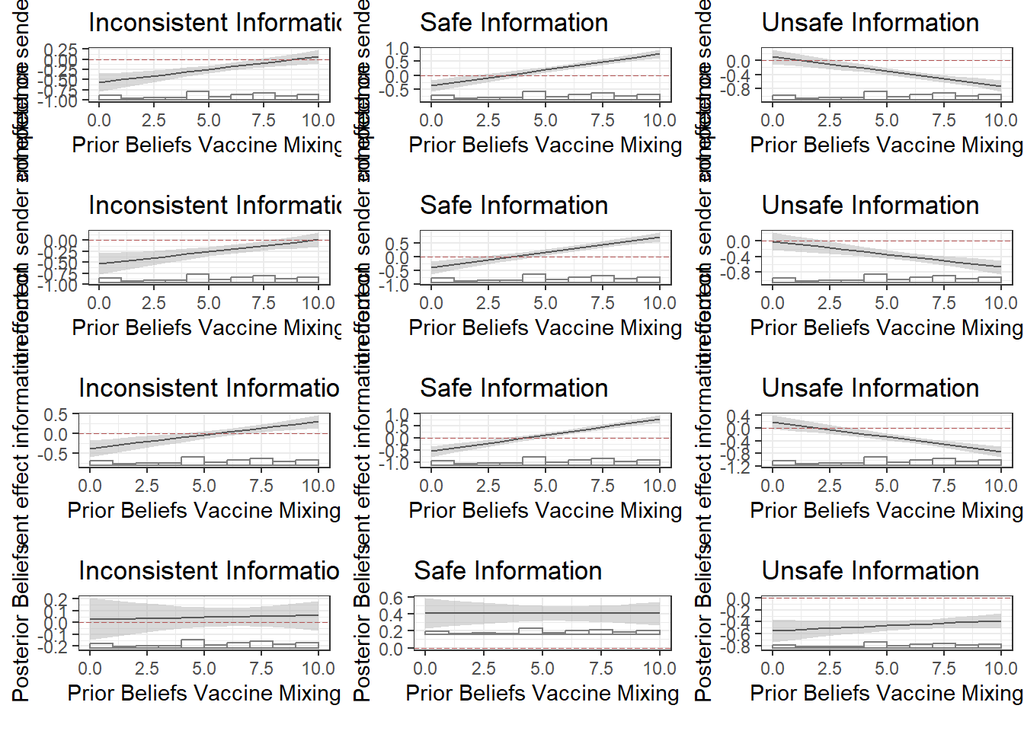

Figure G.1. Effect of information conditional on prior beliefs about vaccine mixing.

```r
cate_dat_g1 <- thirdwave |>
  mutate(
    unsafe = as.numeric(info1 == 1 | info1 == 2 & info2 == 1 | info2 == 2),
    safe = as.numeric(info1 == 3 | info1 == 4 & info2 == 3 | info2 == 4)
  )

cate_panel <- function(data, y, treat, ylab, title) {
  m <- lm(as.formula(paste(y, "~ prior_mixed *", treat)), data = data)
  interplot::interplot(
    m = m,
    var1 = treat,
    var2 = "prior_mixed",
    hist = TRUE,
    adjCI = FALSE
  ) +
    geom_hline(
      yintercept = 0,
      linetype = "longdash",
      linewidth = 0.35,
      colour = "#B55555"
    ) +
    ylab(ylab) +
    xlab("Prior Beliefs Vaccine Mixing") +
    ggtitle(title) +
    theme_bw()
}

M1_plot <- cate_panel(cate_dat_g1, "credible", "inconsistent", "Treatment effect on sender credibility", "Inconsistent Information")
M2_plot <- cate_panel(cate_dat_g1, "credible", "safe", "Treatment effect on sender credibility", "Safe Information")
M3_plot <- cate_panel(cate_dat_g1, "credible", "unsafe", "Treatment effect on sender credibility", "Unsafe Information")
M4_plot <- cate_panel(cate_dat_g1, "competent", "inconsistent", "Treatment effect on sender competence", "Inconsistent Information")
M5_plot <- cate_panel(cate_dat_g1, "competent", "safe", "Treatment effect on sender competence", "Safe Information")
M6_plot <- cate_panel(cate_dat_g1, "competent", "unsafe", "Treatment effect on sender competence", "Unsafe Information")
M7_plot <- cate_panel(cate_dat_g1, "correct", "inconsistent", "Treatment effect information correct", "Inconsistent Information")
M8_plot <- cate_panel(cate_dat_g1, "correct", "safe", "Treatment effect information correct", "Safe Information")
M9_plot <- cate_panel(cate_dat_g1, "correct", "unsafe", "Treatment effect information correct", "Unsafe Information")
M7a_plot <- cate_panel(cate_dat_g1, "post_mixed", "inconsistent", "Posterior Beliefs", "Inconsistent Information")
M8a_plot <- cate_panel(cate_dat_g1, "post_mixed", "safe", "Posterior Beliefs", "Safe Information")
M9a_plot <- cate_panel(cate_dat_g1, "post_mixed", "unsafe", "Posterior Beliefs", "Unsafe Information")

fig_1 <- grid.arrange(
  M1_plot, M2_plot, M3_plot,
  M4_plot, M5_plot, M6_plot,
  M7_plot, M8_plot, M9_plot,
  M7a_plot, M8a_plot, M9a_plot,
  ncol = 3
)
```

```r
ggsave(file.path(fig_dir, "fig_1.pdf"), fig_1, width = 10, height = 9)
```

## 5.18 Table G.5. High priors

## 5.19 Table G.6. Medium priors

## 5.20 Table G.7. Low priors

Cuts: low `< 3.3`, medium `(3.3, 6.6)`, high `> 6.6`. The previous high-priors table used `< 6.6` (low and medium stacked). Demeaning is within subgroup.

```r
dat_low <- filter(thirdwave, prior_mixed < prior_low)
dat_med <- filter(thirdwave, prior_mixed > prior_low & prior_mixed < prior_high)
dat_high <- filter(thirdwave, prior_mixed > prior_high)

c(
  low = nrow(dat_low),
  med = nrow(dat_med),
  high = nrow(dat_high),
  excluded_at_cuts = nrow(thirdwave) - nrow(dat_low) - nrow(dat_med) - nrow(dat_high)
)
```

```
             low              med             high excluded_at_cuts
            1978             3373             5105                0
```

```r
sat_low <- fit_saturated_list(dat_low)
sat_med <- fit_saturated_list(dat_med)
sat_high <- fit_saturated_list(dat_high)

tab_sat_low <- write_texreg(
  sat_low,
  file = file.path(fig_dir, "tab_1_low_priors.tex"),
  caption = "Fully saturated model, subjects with low priors",
  label = "tab:saturated_low_priors"
)
tab_sat_med <- write_texreg(
  sat_med,
  file = file.path(fig_dir, "tab_1_med_priors.tex"),
  caption = "Fully saturated model, subjects with middling priors",
  label = "tab:saturated_med_priors"
)
tab_sat_high <- write_texreg(
  sat_high,
  file = file.path(fig_dir, "tab_1_high_priors.tex"),
  caption = "Fully saturated model, subjects with high priors",
  label = "tab:saturated_high_priors"
)
```

```r
show_htmlreg(sat_high, caption = "Table G.5. Fully saturated model, subjects with high priors")
```

Table G.5. Fully saturated model, subjects with high priors

|  | Credible | Competent | Correct | Belief (msg 2) | Behave (msg 2) |
| --- | --- | --- | --- | --- | --- |
| Inconsistent | -0.03 | -0.07 | 0.23*** | -0.37*** | -0.29*** |
|  | (0.06) | (0.07) | (0.07) | (0.06) | (0.08) |
| Scientific (sender identity) | 0.97*** | 1.57*** | 0.50*** | 0.02 | 0.10 |
|  | (0.06) | (0.07) | (0.07) | (0.06) | (0.08) |
| Science (deemed optimum can change) | 0.25*** | 0.33*** | 0.24*** | 0.03 | 0.09 |
|  | (0.06) | (0.07) | (0.07) | (0.06) | (0.08) |
| Inconsistent $\times$ Scientific | 0.07 | 0.03 | -0.20 | -0.07 | -0.11 |
|  | (0.13) | (0.14) | (0.14) | (0.12) | (0.17) |
| Inconsistent $\times$ Science | 0.20 | 0.20 | 0.23* | -0.01 | 0.17 |
|  | (0.13) | (0.14) | (0.14) | (0.12) | (0.17) |
| Sender: scientific $\times$ Science | 0.04 | 0.13 | -0.01 | 0.15 | -0.08 |
|  | (0.13) | (0.14) | (0.14) | (0.12) | (0.17) |
| Inconsistent $\times$ Scientific $\times$ Science | 0.26 | 0.55** | 0.45 | 0.13 | 0.18 |
|  | (0.26) | (0.27) | (0.27) | (0.24) | (0.33) |
| R<sup>2</sup> | 0.08 | 0.12 | 0.05 | 0.61 | 0.46 |
| Adj. R<sup>2</sup> | 0.08 | 0.12 | 0.04 | 0.61 | 0.45 |
| Num. obs. | 5105 | 5105 | 5105 | 5105 | 5105 |
| RMSE | 2.28 | 2.44 | 2.43 | 2.16 | 2.96 |

***p < 0.01; **p < 0.05; *p < 0.1

```r
show_htmlreg(sat_med, caption = "Table G.6. Fully saturated model, subjects with middling priors")
```

Table G.6. Fully saturated model, subjects with middling priors

|  | Credible | Competent | Correct | Belief (msg 2) | Behave (msg 2) |
| --- | --- | --- | --- | --- | --- |
| Inconsistent | -0.30*** | -0.30*** | -0.15* | -0.53*** | -0.55*** |
|  | (0.08) | (0.08) | (0.08) | (0.07) | (0.11) |
| Scientific (sender identity) | 1.02*** | 1.47*** | 0.69*** | 0.16** | 0.30*** |
|  | (0.08) | (0.08) | (0.08) | (0.07) | (0.11) |
| Science (deemed optimum can change) | 0.33*** | 0.38*** | 0.36*** | 0.16** | 0.11 |
|  | (0.08) | (0.08) | (0.08) | (0.07) | (0.11) |
| Inconsistent $\times$ Scientific | -0.09 | -0.10 | -0.15 | -0.08 | 0.02 |
|  | (0.16) | (0.16) | (0.17) | (0.15) | (0.23) |
| Inconsistent $\times$ Science | 0.07 | 0.20 | 0.26 | -0.18 | -0.19 |
|  | (0.16) | (0.16) | (0.17) | (0.15) | (0.23) |
| Sender: scientific $\times$ Science | -0.21 | -0.20 | -0.36** | -0.00 | 0.19 |
|  | (0.16) | (0.16) | (0.17) | (0.15) | (0.23) |
| Inconsistent $\times$ Scientific $\times$ Science | 0.09 | -0.07 | -0.26 | -0.61** | -0.10 |
|  | (0.32) | (0.33) | (0.34) | (0.29) | (0.45) |
| R<sup>2</sup> | 0.06 | 0.11 | 0.03 | 0.02 | 0.04 |
| Adj. R<sup>2</sup> | 0.06 | 0.10 | 0.03 | 0.02 | 0.03 |
| Num. obs. | 3373 | 3373 | 3373 | 3373 | 3373 |
| RMSE | 2.32 | 2.35 | 2.43 | 2.14 | 3.27 |

***p < 0.01; **p < 0.05; *p < 0.1

```r
show_htmlreg(sat_low, caption = "Table G.7. Fully saturated model, subjects with low priors")
```

Table G.7. Fully saturated model, subjects with low priors

|  | Credible | Competent | Correct | Belief (msg 2) | Behave (msg 2) |
| --- | --- | --- | --- | --- | --- |
| Inconsistent | -0.48*** | -0.47*** | -0.29** | -0.39*** | -0.26** |
|  | (0.12) | (0.13) | (0.12) | (0.10) | (0.10) |
| Scientific (sender identity) | 1.29*** | 1.65*** | 1.01*** | 0.11 | 0.07 |
|  | (0.12) | (0.13) | (0.12) | (0.10) | (0.10) |
| Science (deemed optimum can change) | 0.50*** | 0.55*** | 0.38*** | 0.07 | 0.21** |
|  | (0.12) | (0.13) | (0.12) | (0.10) | (0.10) |
| Inconsistent $\times$ Scientific | -0.14 | -0.22 | 0.05 | 0.15 | 0.06 |
|  | (0.25) | (0.25) | (0.25) | (0.20) | (0.21) |
| Inconsistent $\times$ Science | 0.06 | 0.02 | 0.02 | 0.02 | 0.07 |
|  | (0.25) | (0.25) | (0.25) | (0.20) | (0.21) |
| Sender: scientific $\times$ Science | 0.24 | 0.28 | 0.39 | 0.02 | 0.44** |
|  | (0.25) | (0.25) | (0.24) | (0.20) | (0.21) |
| Inconsistent $\times$ Scientific $\times$ Science | -0.48 | -0.95* | -0.72 | -0.58 | -0.45 |
|  | (0.50) | (0.50) | (0.49) | (0.40) | (0.41) |
| R<sup>2</sup> | 0.07 | 0.10 | 0.05 | 0.65 | 0.73 |
| Adj. R<sup>2</sup> | 0.06 | 0.09 | 0.05 | 0.65 | 0.72 |
| Num. obs. | 1978 | 1978 | 1978 | 1978 | 1978 |
| RMSE | 2.78 | 2.79 | 2.73 | 2.23 | 2.31 |

***p < 0.01; **p < 0.05; *p < 0.1

## 5.21 Table G.8. ITT

## 5.22 Table G.9. IV

Same 0/1 `inconsistent` as Figure 5. Outcomes match Table 3 (including recoded message-2 measures). Overleaf currently hardcodes `post_mixed` and `belief_update_abs` instead.

```r
tab_itt <- texreg::texreg(
  models_basic,
  include.ci = FALSE,
  custom.model.names = mod_names,
  caption = "ITT: inconsistency assignment",
  stars = c(0.01, 0.05, 0.1),
  custom.note = table_note_outcomes
)
write(tab_itt, file = file.path(fig_dir, "tab_itt.tex"))

tab_iv <- texreg::texreg(
  models_iv,
  include.ci = FALSE,
  custom.model.names = mod_names,
  caption = "IV: perceived inconsistency instrumented by assignment",
  stars = c(0.01, 0.05, 0.1),
  custom.note = table_note_outcomes
)
write(tab_iv, file = file.path(fig_dir, "tab_iv.tex"))
```

```r
show_htmlreg(
  models_basic,
  caption = "Table G.8. ITT: inconsistency assignment. Same outcomes as Table 3."
)
```

Table G.8. ITT: inconsistency assignment. Same outcomes as Table 3.

|  | Credible | Competent | Correct | Belief (msg 2) | Behave (msg 2) |
| --- | --- | --- | --- | --- | --- |
| Inconsistent | -0.23*** | -0.25*** | -0.02 | -0.43*** | -0.37*** |
|  | (0.05) | (0.06) | (0.06) | (0.06) | (0.08) |
| R<sup>2</sup> | 0.00 | 0.00 | 0.00 | 0.00 | 0.00 |
| Adj. R<sup>2</sup> | 0.00 | 0.00 | -0.00 | 0.00 | 0.00 |
| Num. obs. | 10456 | 10456 | 10456 | 10456 | 10456 |
| RMSE | 2.80 | 2.93 | 2.92 | 3.14 | 3.88 |

***p < 0.01; **p < 0.05; *p < 0.1

```r
show_htmlreg(
  models_iv,
  caption = "Table G.9. IV: perceived inconsistency instrumented by assignment. Same outcomes as Table 3.",
  coef_map = iv_coef_map
)
```

Table G.9. IV: perceived inconsistency instrumented by assignment. Same outcomes as Table 3.

|  | Credible | Competent | Correct | Belief (msg 2) | Behave (msg 2) |
| --- | --- | --- | --- | --- | --- |
| Perceived inconsistency | -0.28*** | -0.30*** | -0.02 | -0.54*** | -0.47*** |
|  | (0.06) | (0.07) | (0.07) | (0.08) | (0.10) |
| R<sup>2</sup> | 0.13 | 0.13 | 0.01 | -0.19 | -0.08 |
| Adj. R<sup>2</sup> | 0.13 | 0.13 | 0.01 | -0.19 | -0.08 |
| Num. obs. | 10357 | 10357 | 10357 | 10357 | 10357 |
| RMSE | 2.61 | 2.73 | 2.90 | 3.44 | 4.04 |

***p < 0.01; **p < 0.05; *p < 0.1

# 6 6. Additional

Objects not in the paper: four-type OLS by prior, pooled raw means, IV first-stage plot, unsaturated specification.

## 6.1 Information types by prior

Predicted outcomes by four-level message type and prior (reference: unsafe-unsafe).

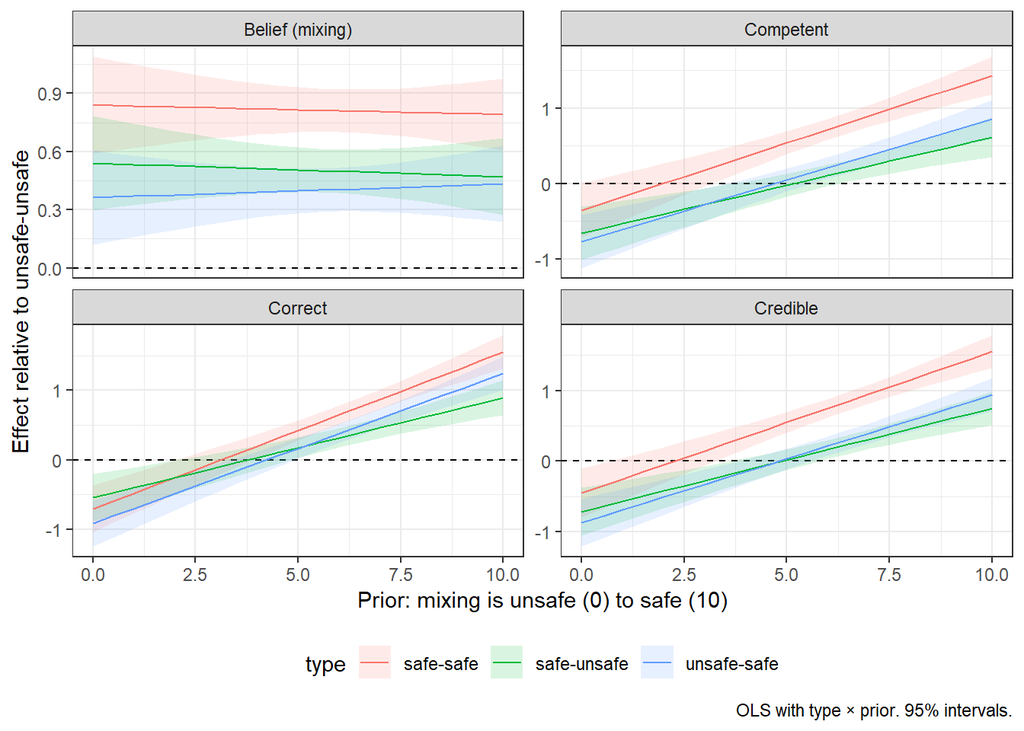

Additional (not in paper). Information types by prior, relative to unsafe-unsafe.

```r
cate_dat <- thirdwave |>
  mutate(
    types = factor(types, c("unsafe-unsafe", "unsafe-safe", "safe-unsafe", "safe-safe"))
  )

cate_fits <- lapply(c("credible", "competent", "correct", "post_mixed"), function(y) {
  lm_robust(as.formula(paste(y, "~ types * prior_mixed")), data = cate_dat)
})
names(cate_fits) <- c("Credible", "Competent", "Correct", "Belief (mixing)")

grid_prior <- seq(0, 10, by = 0.5)
cate_plot_dat <- map_dfr(names(cate_fits), function(nm) {
  fit <- cate_fits[[nm]]
  b <- coef(fit)
  V <- vcov(fit)
  types_ok <- c("unsafe-safe", "safe-unsafe", "safe-safe")
  map_dfr(types_ok, function(tp) {
    tterm <- paste0("types", tp)
    pterm <- paste0("types", tp, ":prior_mixed")
    tibble(prior = grid_prior, outcome = nm, type = tp) |>
      mutate(
        estimate = b[[tterm]] + b[[pterm]] * prior,
        se = sqrt(V[tterm, tterm] + (prior^2) * V[pterm, pterm] + 2 * prior * V[tterm, pterm]),
        conf.low = estimate - 1.96 * se,
        conf.high = estimate + 1.96 * se
      )
  })
})

fig_types_by_prior <- cate_plot_dat |>
  ggplot(aes(prior, estimate, color = type, fill = type)) +
  geom_hline(yintercept = 0, linetype = "dashed") +
  geom_ribbon(aes(ymin = conf.low, ymax = conf.high), alpha = 0.15, color = NA) +
  geom_line() +
  facet_wrap(~outcome, scales = "free_y") +
  xlab("Prior: mixing is unsafe (0) to safe (10)") +
  ylab("Effect relative to unsafe-unsafe") +
  labs(caption = "OLS with type × prior. 95% intervals.") +
  theme_bw() +
  theme(legend.position = "bottom")

fig_types_by_prior
```

```r
ggsave(
  file.path(fig_dir, "additional_info_types_by_prior.pdf"),
  fig_types_by_prior,
  width = 9,
  height = 6
)
```

## 6.2 Pooled raw means (not in the paper)

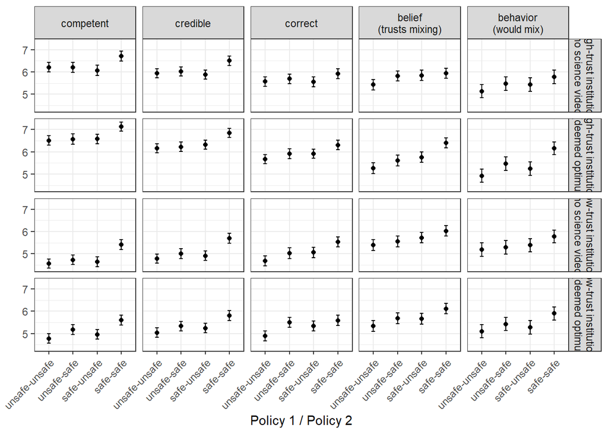

```r
summary_pooled <-
  thirdwave |>
  mutate(
    science = info_treat,
    trust = sender_treat,
    Z = paste0(safe_time1, "/", safe_time2)
  ) |>
  transmute(
    safe_time1, safe_time2, science, trust, Z,
    credible = as.numeric(credible),
    competent = as.numeric(competent),
    correct = as.numeric(correct),
    convinced = post_mixed,
    act = behav_mixed
  ) |>
  pivot_longer(
    c(credible, competent, correct, convinced, act),
    names_to = "Y",
    values_to = "val"
  ) |>
  group_by(safe_time1, safe_time2, science, trust, Z, Y) |>
  summarise(
    n = sum(!is.na(val)),
    mean = mean(val, na.rm = TRUE),
    sd = sd(val, na.rm = TRUE),
    se = sd / sqrt(n),
    tcrit = qt(0.975, df = pmax(n - 1, 1)),
    lwr = mean - tcrit * se,
    upr = mean + tcrit * se,
    .groups = "drop"
  ) |>
  mutate(
    trust_lab = if_else(trust == 1, "high-trust institution", "low-trust institution"),
    science_lab = science_lab(science),
    cond = paste(trust_lab, science_lab, sep = "\n"),
    Z = recode(
      Z,
      "0/0" = "unsafe-unsafe",
      "0/1" = "unsafe-safe",
      "1/0" = "safe-unsafe",
      "1/1" = "safe-safe"
    ),
    Z = factor(Z, c("unsafe-unsafe", "unsafe-safe", "safe-unsafe", "safe-safe")),
    Y = factor(
      Y,
      c("competent", "credible", "correct", "convinced", "act"),
      c("competent", "credible", "correct", "belief\n(trusts mixing)", "behavior\n(would mix)")
    )
  )

raw_patterns <- ggplot(summary_pooled, aes(x = Z, y = mean)) +
  facet_grid(cond ~ Y) +
  geom_point() +
  geom_errorbar(aes(ymin = lwr, ymax = upr), width = 0.15) +
  theme_bw() +
  theme(axis.text.x = element_text(angle = 45, hjust = 1)) +
  labs(x = "Policy 1 / Policy 2", y = "")

raw_patterns
```

```r
ggsave(file.path(fig_dir, "raw_patterns.pdf"), raw_patterns, width = 8, height = 8)
```

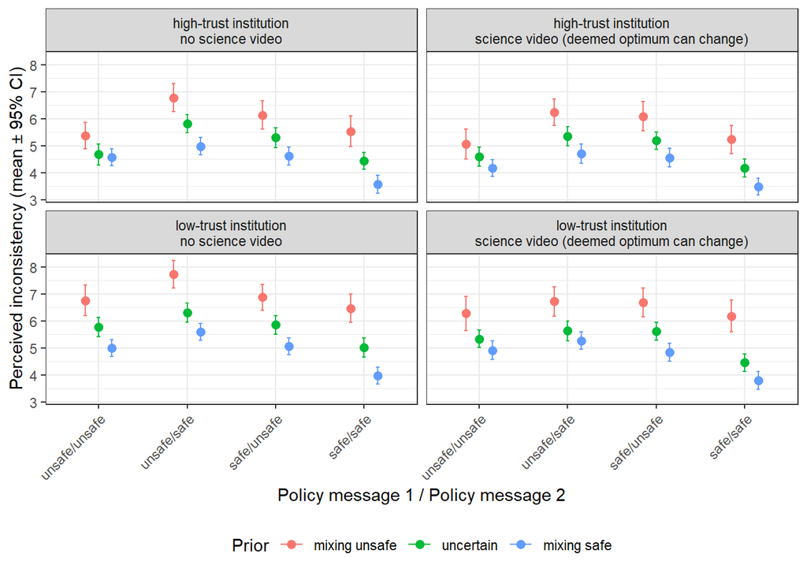

```r
tm_summary <- thirdwave |>
  mutate(
    prior = prior_group(prior_mixed),
    science = info_treat,
    trust = sender_treat,
    Z = paste0(safe_time1, "/", safe_time2),
    val = as.numeric(treatment_measurement)
  ) |>
  group_by(safe_time1, safe_time2, science, trust, Z, prior) |>
  summarise(
    n = sum(!is.na(val)),
    mean = mean(val, na.rm = TRUE),
    sd = sd(val, na.rm = TRUE),
    se = sd / sqrt(n),
    tcrit = qt(0.975, df = pmax(n - 1, 1)),
    lwr = mean - tcrit * se,
    upr = mean + tcrit * se,
    .groups = "drop"
  ) |>
  mutate(
    trust_lab = if_else(trust == 1, "high-trust institution", "low-trust institution"),
    science_lab = science_lab(science),
    cond = paste(trust_lab, science_lab, sep = "\n"),
    Z_lab = recode(
      Z,
      "0/0" = "unsafe/unsafe",
      "0/1" = "unsafe/safe",
      "1/0" = "safe/unsafe",
      "1/1" = "safe/safe"
    ),
    Z_lab = factor(Z_lab, c("unsafe/unsafe", "unsafe/safe", "safe/unsafe", "safe/safe"))
  )

raw_tm <- ggplot(tm_summary, aes(x = Z_lab, y = mean, color = prior, group = prior)) +
  facet_wrap(~cond, ncol = 2) +
  geom_point(position = position_dodge(0.45), size = 2.3) +
  geom_errorbar(
    aes(ymin = lwr, ymax = upr),
    width = 0.12,
    position = position_dodge(0.45)
  ) +
  theme_bw() +
  labs(
    x = "Policy message 1 / Policy message 2",
    y = "Perceived inconsistency (mean ± 95% CI)",
    color = "Prior"
  ) +
  theme(legend.position = "bottom", axis.text.x = element_text(angle = 45, hjust = 1))

raw_tm
```

```r
ggsave(file.path(fig_dir, "iv_first_stage.pdf"), raw_tm, width = 7, height = 8)
```

## 6.3 Unsaturated specification (not in the paper)

```r
sat_unsat <- lapply(outcomes, function(y) {
  lm_robust(as.formula(paste(y, "~ inconsistent * trusted * science")), data = thirdwave)
})

tab_1 <- texreg::texreg(
  sat_unsat,
  include.ci = FALSE,
  custom.model.names = mod_names,
  caption = "Saturated in T1 T2 T5 only (not in paper)",
  omit.coef = c("(Intercept)"),
  stars = c(0.001, 0.01, 0.05, 0.1)
)
write(tab_1, file = file.path(fig_dir, "tab_1.tex"))
```

```r
show_htmlreg(
  sat_unsat,
  caption = "Additional (not in paper). Saturated in T1 T2 T5 only.",
  coef_map = NULL
)
```

Additional (not in paper). Saturated in T1 T2 T5 only.

|  | Credible | Competent | Correct | Belief (msg 2) | Behave (msg 2) |
| --- | --- | --- | --- | --- | --- |
| (Intercept) | 5.24*** | 4.98*** | 5.10*** | 5.32*** | 5.29*** |
|  | (0.08) | (0.08) | (0.08) | (0.09) | (0.11) |
| inconsistent | -0.28** | -0.30*** | -0.06 | -0.40*** | -0.34** |
|  | (0.11) | (0.11) | (0.12) | (0.12) | (0.15) |
| trusted | 0.98*** | 1.48*** | 0.65*** | -0.06 | 0.03 |
|  | (0.11) | (0.11) | (0.11) | (0.12) | (0.15) |
| science | 0.19* | 0.21* | 0.14 | 0.07 | 0.11 |
|  | (0.11) | (0.11) | (0.12) | (0.12) | (0.15) |
| inconsistent:trusted | 0.01 | -0.03 | -0.07 | 0.13 | 0.04 |
|  | (0.15) | (0.16) | (0.16) | (0.17) | (0.21) |
| inconsistent:science | 0.14 | 0.17 | 0.24 | 0.03 | 0.02 |
|  | (0.16) | (0.16) | (0.16) | (0.17) | (0.21) |
| trusted:science | 0.09 | 0.14 | 0.09 | 0.25 | 0.19 |
|  | (0.15) | (0.15) | (0.16) | (0.17) | (0.21) |
| inconsistent:trusted:science | -0.10 | -0.10 | -0.18 | -0.41* | -0.22 |
|  | (0.22) | (0.22) | (0.23) | (0.25) | (0.30) |
| R<sup>2</sup> | 0.04 | 0.07 | 0.01 | 0.01 | 0.00 |
| Adj. R<sup>2</sup> | 0.04 | 0.07 | 0.01 | 0.00 | 0.00 |
| Num. obs. | 10456 | 10456 | 10456 | 10456 | 10456 |
| RMSE | 2.75 | 2.82 | 2.90 | 3.14 | 3.88 |

***p < 0.01; **p < 0.05; *p < 0.1

# 7 7. Export

Respondent-level data are not saved. `lm_robust` objects include the estimation frame; we store coefficients and table strings only.

```r
coef_tab <- function(mods, labels = mod_names) {
  purrr::map2_dfr(mods, labels, function(m, nm) {
    tibble::tibble(
      model = nm,
      term = names(m$coefficients),
      estimate = as.numeric(m$coefficients),
      std.error = as.numeric(m$std.error)
    )
  })
}

estimates <- list(
  treatment_means = treatment_means,
  tab_sat = tab_sat,
  saturated = coef_tab(saturated),
  sat_0 = coef_tab(sat_0),
  sat_1 = coef_tab(sat_1),
  sat_priors = coef_tab(sat_priors),
  sat_low = coef_tab(sat_low),
  sat_med = coef_tab(sat_med),
  sat_high = coef_tab(sat_high),
  man_science = coef_tab(list(man_science), "science_check"),
  man_iv = coef_tab(list(man_iv), "first_stage"),
  itt = coef_tab(models_basic),
  iv = coef_tab(models_iv),
  oxcgrt_gri = coef_tab(a1_models, a1_names)
)

save(estimates, file = file.path(fig_dir, "analysis.Rdata"))
```